# Decision Trees and Random Forests

Yunting Chiu

2021-06-16

We will be using this lab to explore decision trees and random forests using the `palmerpenguins` package. We will also use a couple of other packages such as `rpart.plot`, `rpart`, `ranger`, and `vip`.

```r
library(tidymodels)
library(palmerpenguins)
```

# Split the Data

```r
penguins_split <- initial_split(penguins)
set.seed(1234)
penguins_train <- training(penguins_split)
penguins_test <- testing(penguins_split)
```

# Decision Tree

1. Fit a decision tree using `decision_tree()`, and visualize the structure of the tree.
- The system can automatically generalize the model specification by clicking the **Addins** tab in the header of RStudio

```r
decision_tree_rpart_spec <-
  decision_tree() %>%
  set_engine('rpart') %>%
  set_mode('classification')
```

```r
dt_fit <- fit(decision_tree_rpart_spec, species ~., data = penguins_train)
dt_fit
```

```
## parsnip model object
##
## Fit time:  9ms
## n= 258
##
## node), split, n, loss, yval, (yprob)
##       * denotes terminal node
##
## 1) root 258 148 Adelie (0.42635659 0.20542636 0.36821705)
##   2) flipper_length_mm< 206.5 160  51 Adelie (0.68125000 0.31250000 0.00625000)
##     4) bill_length_mm< 44.2 110   3 Adelie (0.97272727 0.02727273 0.00000000) *
##     5) bill_length_mm>=44.2 50   3 Chinstrap (0.04000000 0.94000000 0.02000000) *
##   3) flipper_length_mm>=206.5 98   4 Gentoo (0.01020408 0.03061224 0.95918367) *
```

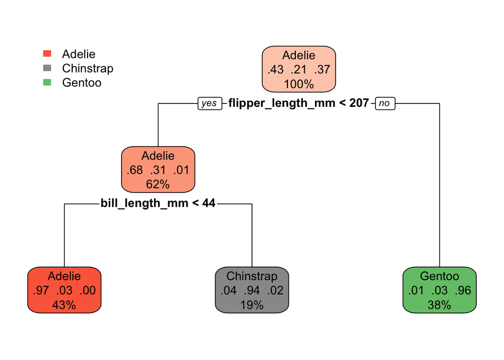

```r
library(rpart.plot)
rpart.plot(dt_fit$fit)
```

2. Try different values of the hyperparameters for the tree and see how the shape of the tree changes.

```r
decision_tree_rpart_spec_lambda <-
  decision_tree(cost_complexity = 0.5) %>%
  set_engine('rpart') %>%
  set_mode('classification')
dt_fit_lambda <- fit(decision_tree_rpart_spec_lambda, species ~., data = penguins_train)
dt_fit_lambda
```

```
## parsnip model object
##
## Fit time:  4ms
## n= 258
##
## node), split, n, loss, yval, (yprob)
##       * denotes terminal node
##
## 1) root 258 148 Adelie (0.42635659 0.20542636 0.36821705)
##   2) flipper_length_mm< 206.5 160  51 Adelie (0.68125000 0.31250000 0.00625000) *
##   3) flipper_length_mm>=206.5 98   4 Gentoo (0.01020408 0.03061224 0.95918367) *
```

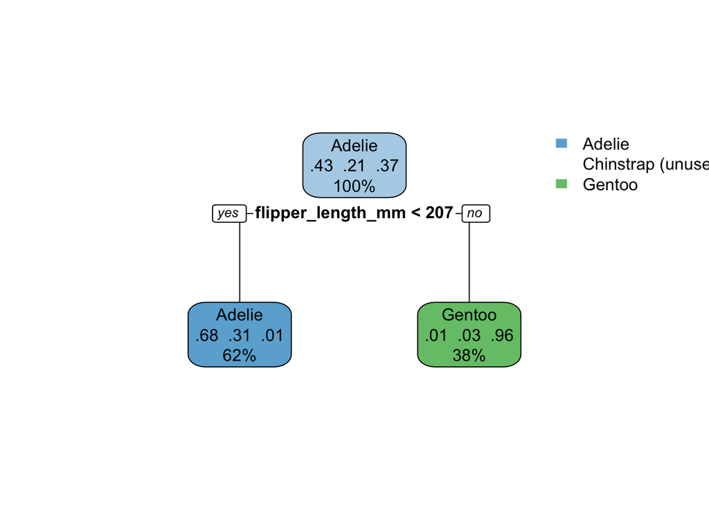

```r
rpart.plot(dt_fit_lambda$fit)
```

# Variable Importance Plots

3. Use the `vip` package to showcase the variable importance.

With respect to the `species` variable, the `vi()` and `vip()` show the important variables in descending order. We can see the first important variable is `flipper_length_mm`.

```r
library(vip)
vi(dt_fit)
```

```
## # A tibble: 5 x 2
##   Variable          Importance
##   <chr>                  <dbl>
## 1 flipper_length_mm       96.1
## 2 bill_length_mm          93.4
## 3 bill_depth_mm           73.3
## 4 body_mass_g             63.5
## 5 island                  52.8
```

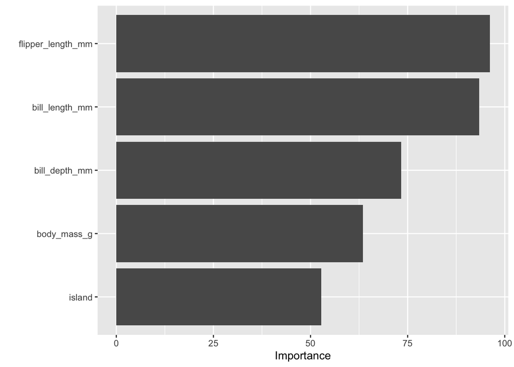

```r
vip(dt_fit)
```

# Random Forest Models

4. Fit a random forest model using `rand_forest()`. What Do you see in the output?

We set the importance as impurity in the model specification.

```r
rand_forest_ranger_spec <-
  rand_forest() %>%
  set_engine('ranger', importance = "impurity") %>%
  set_mode('classification')
rand_forest_ranger_spec
```

```
## Random Forest Model Specification (classification)
##
## Engine-Specific Arguments:
##   importance = impurity
##
## Computational engine: ranger
```

We can see the target node size is 10 in the algorithm.

```r
set.seed(4321)
rf_fit <- fit(rand_forest_ranger_spec,species ~., data = penguins_train)
rf_fit
```

```
## parsnip model object
##
## Fit time:  55ms
## Ranger result
##
## Call:
##  ranger::ranger(x = maybe_data_frame(x), y = y, importance = ~"impurity",      num.threads = 1, verbose = FALSE, seed = sample.int(10^5,          1), probability = TRUE)
##
## Type:                             Probability estimation
## Number of trees:                  500
## Sample size:                      251
## Number of independent variables:  7
## Mtry:                             2
## Target node size:                 10
## Variable importance mode:         impurity
## Splitrule:                        gini
## OOB prediction error (Brier s.):  0.01752356
```

5. Use the `vip` package to showcase the variable importance for the random forest.

According to the results of the random forest model, we can now conclude that the most important variable is bill_length_mm, which has a large value greater than 50.

```r
vi(rf_fit$fit)
```

```
## # A tibble: 7 x 2
##   Variable          Importance
##   <chr>                  <dbl>
## 1 bill_length_mm        57.3
## 2 flipper_length_mm     36.6
## 3 bill_depth_mm         25.1
## 4 body_mass_g           19.3
## 5 island                15.7
## 6 sex                    0.768
## 7 year                   0.719
```

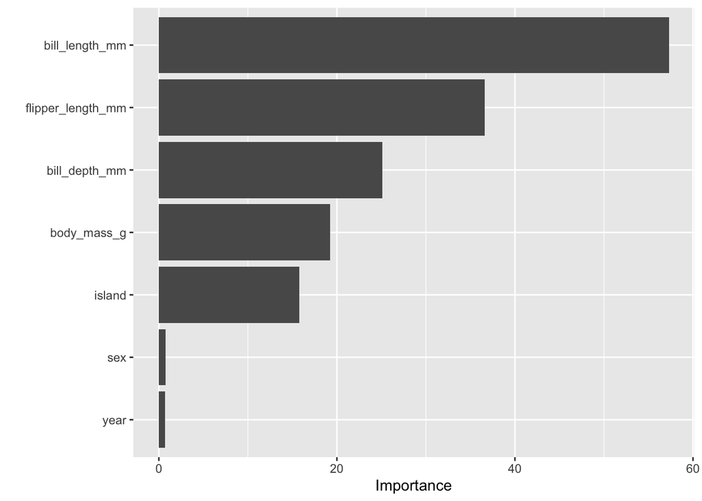

```r
vip(rf_fit$fit)
```

# Reference

- https://stats.stackexchange.com/questions/179541/complexity-parameter-in-decision-tree